# Measured hypertension in Kenyan outpatient attenders

Dataset 4: Kenya hypertension screening survey

RSR feasibility analysis

2026-08-03

# Introduction

Hypertension is the leading modifiable cardiovascular risk factor in sub-Saharan Africa, and Kenya’s NCD strategy relies heavily on opportunistic screening of people already attending health facilities. This dataset is a cross-sectional screening survey of 1444 adults recruited at three types of Kenyan outpatient facility - a government (public) facility, a private facility and a faith-based mission facility - in which every participant had blood pressure measured three times and completed a WHO STEPS-style questionnaire on demography, behaviour and self-reported morbidity. Knowing which attender characteristics predict a raised measured pressure tells a clinic who to prioritise when it cannot screen everybody.

**Aim.** Among these Kenyan outpatient attenders, we examined which of age band, sex, education, BMI category, current smoking, current alcohol use, physical activity and self-reported diabetes are independently associated with hypertension on measured blood pressure, mutually adjusting for the others.

This is a *Purpose 3* analysis: several predictors are of interest and the question is which remain associated with the outcome after mutual adjustment.

# Methods

**Data source.** A cross-sectional facility-based screening survey of 1444 adults aged 18 and over attending outpatient services at three Kenyan facilities (450 public, 557 private, 437 faith-based). Blood pressure was measured three times and the file carries the average of the three readings.

**Variables.** The outcome is `hypertension`, a binary indicator of raised measured blood pressure derived from the average of the three readings; the modelled event is **hypertension = Yes** (425 of 1444, 29.4%). Predictors are age band (reference *26-35*); sex (reference *Female*); education (reference *No School*); WHO BMI category (reference *Healthy*); current smoking (reference *No*); current alcohol use (reference *No*); meeting the physical-activity recommendation (reference *No*); and self-reported diabetes (reference *no*, with *unknown* retained as a substantive third level rather than treated as missing).

**`systolic_bp` and `diastolic_bp` are excluded by construction.** `hypertension` in this file *is* the measured average blood pressure crossing the diagnostic threshold - it is a coarsened version of the two continuous pressures, not a separate fact about the participant. Putting either pressure on the right-hand side would produce complete or near-complete separation, absurd odds ratios and a model that says only “high blood pressure is associated with high blood pressure”. This is the single most likely way to destroy this analysis. The relationship is not hidden by noise, it is definitional.

**`prior_htn_diagnosis` is excluded from the main model** and examined separately below. A self-reported earlier diagnosis is a genuinely different construct - it is about contact with care - but the two variables have a messy bidirectional relationship: a diagnosis follows from previously high pressure, and then leads to treatment that lowers today’s measured pressure. Without a medication variable (there is none in this file) that loop cannot be broken, so it belongs in a sensitivity analysis, not the main model.

**BMI is categorical, not continuous.** Only the WHO `bmi_category` label is supplied, so no per-unit BMI odds ratio can be reported. Indeed **no predictor in this file is continuous** - age is banded too - so every estimate below is a contrast between broad groups and within-band residual confounding is certain.

**Statistical analysis.** Logistic regression via `glm(family = binomial)`, justified because the outcome is binary; estimates are reported as odds ratios. We fitted a univariable model for each predictor first, then a single multivariable model containing all eight. Predictors were chosen in advance on subject-matter grounds, not by significance. Significance threshold 0.05; estimates are reported with 95% confidence intervals. Assumptions were checked with `performance::check_model()`. Analysis used R version 4.6.0 (2026-04-24) with tidyverse, gtsummary and performance.

**Missing data.** Complete-case analysis: 1376 of 1444 rows were analysed (68 dropped, 4.7%), containing 405 events. The outcome and four predictors are 100% complete; the losses come from `bmi_category` (31 missing), `education` (21) and `age_group` (17). `monthly_income`, missing for 453 participants (31.4%), is not in the main model; the section *The cost of `monthly_income`* below reports what including it would do.

# Results

## Sample characteristics

**Table 1. Sample characteristics by measured hypertension status.**

| **Characteristic** | **N** | **Overall** N = 1,376<sup>1</sup> | **No** N = 971<sup>1</sup> | **Yes** N = 405<sup>1</sup> |
| --- | --- | --- | --- | --- |
| Age band (years) | 1,376 |  |  |  |
| 26-35 |  | 287 (21%) | 248 (26%) | 39 (9.6%) |
| 18-25 |  | 100 (7.3%) | 94 (9.7%) | 6 (1.5%) |
| 36-45 |  | 274 (20%) | 205 (21%) | 69 (17%) |
| 46-55 |  | 256 (19%) | 164 (17%) | 92 (23%) |
| 56-65 |  | 242 (18%) | 142 (15%) | 100 (25%) |
| >65 |  | 217 (16%) | 118 (12%) | 99 (24%) |
| Sex | 1,376 |  |  |  |
| Female |  | 741 (54%) | 547 (56%) | 194 (48%) |
| Male |  | 635 (46%) | 424 (44%) | 211 (52%) |
| Education | 1,376 |  |  |  |
| No School |  | 178 (13%) | 121 (12%) | 57 (14%) |
| Primary |  | 234 (17%) | 136 (14%) | 98 (24%) |
| Secondary |  | 363 (26%) | 240 (25%) | 123 (30%) |
| Tertiary |  | 601 (44%) | 474 (49%) | 127 (31%) |
| BMI category (WHO) | 1,376 |  |  |  |
| Healthy |  | 547 (40%) | 415 (43%) | 132 (33%) |
| Underweight |  | 80 (5.8%) | 70 (7.2%) | 10 (2.5%) |
| Overweight |  | 444 (32%) | 311 (32%) | 133 (33%) |
| Obese |  | 305 (22%) | 175 (18%) | 130 (32%) |
| Current smoker | 1,376 | 89 (6.5%) | 56 (5.8%) | 33 (8.1%) |
| Current alcohol use | 1,376 | 114 (8.3%) | 71 (7.3%) | 43 (11%) |
| Meets activity recommendation | 1,376 | 615 (45%) | 448 (46%) | 167 (41%) |
| Self-reported diabetes | 1,376 |  |  |  |
| no |  | 937 (68%) | 683 (70%) | 254 (63%) |
| yes |  | 187 (14%) | 115 (12%) | 72 (18%) |
| unknown |  | 252 (18%) | 173 (18%) | 79 (20%) |

<sup>1</sup> n (%)

29.4% of the analytic sample (405 of 1376) had hypertension on measured blood pressure. Hypertensive attenders are much older (49% are over 55 versus 27% of the non-hypertensive), heavier (32% obese versus 18%), more often male and less often tertiary-educated. Smoking and alcohol use are too rare in both groups to show much in a table.

## Exploratory figure

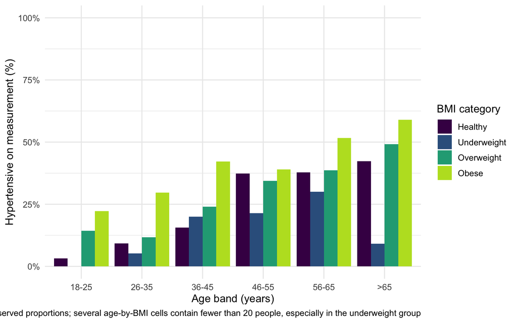

Figure 1. Prevalence of measured hypertension by age band and WHO BMI category.

## Univariable models

| **Characteristic** | **N** | **OR** | **95% CI** | **p-value** |
| --- | --- | --- | --- | --- |
| Age band (years) | 1,376 |  |  |  |
| 26-35 |  | — | — |  |
| 18-25 |  | 0.41 | 0.15, 0.92 | 0.047 |
| 36-45 |  | 2.14 | 1.39, 3.33 | <0.001 |
| 46-55 |  | 3.57 | 2.35, 5.49 | <0.001 |
| 56-65 |  | 4.48 | 2.95, 6.90 | <0.001 |
| >65 |  | 5.34 | 3.49, 8.28 | <0.001 |
| Sex | 1,376 |  |  |  |
| Female |  | — | — |  |
| Male |  | 1.40 | 1.11, 1.77 | 0.004 |
| Education | 1,376 |  |  |  |
| No School |  | — | — |  |
| Primary |  | 1.53 | 1.02, 2.31 | 0.041 |
| Secondary |  | 1.09 | 0.74, 1.60 | 0.7 |
| Tertiary |  | 0.57 | 0.39, 0.83 | 0.003 |
| BMI category (WHO) | 1,376 |  |  |  |
| Healthy |  | — | — |  |
| Underweight |  | 0.45 | 0.21, 0.86 | 0.023 |
| Overweight |  | 1.34 | 1.01, 1.78 | 0.040 |
| Obese |  | 2.34 | 1.73, 3.15 | <0.001 |
| Current smoker | 1,376 |  |  |  |
| No |  | — | — |  |
| Yes |  | 1.45 | 0.92, 2.25 | 0.10 |
| Current alcohol use | 1,376 |  |  |  |
| No |  | — | — |  |
| Yes |  | 1.51 | 1.01, 2.23 | 0.044 |
| Meets activity recommendation | 1,376 |  |  |  |
| No |  | — | — |  |
| Yes |  | 0.82 | 0.65, 1.04 | 0.10 |
| Self-reported diabetes | 1,376 |  |  |  |
| no |  | — | — |  |
| yes |  | 1.68 | 1.21, 2.33 | 0.002 |
| unknown |  | 1.23 | 0.90, 1.66 | 0.2 |

Abbreviations: CI = Confidence Interval, OR = Odds Ratio

Age dominates the crude picture: relative to the 26-35 band, the odds of measured hypertension are OR 3.57 (95% CI 2.35 to 5.49) at 46-55, OR 4.48 (95% CI 2.95 to 6.90) at 56-65 and OR 5.34 (95% CI 3.49 to 8.28) above 65 (all p < 0.001), a clean monotonic gradient. Obesity carries OR 2.34 (95% CI 1.73 to 3.15) relative to healthy weight (p < 0.001), and underweight OR 0.45 (95% CI 0.21 to 0.86) (p = 0.023). Men have OR 1.40 (95% CI 1.11 to 1.77) (p = 0.004). Self-reported diabetes carries OR 1.68 (95% CI 1.21 to 2.33) (p = 0.002) and tertiary education OR 0.57 (95% CI 0.39 to 0.83) (p = 0.003), i.e. crudely protective. Alcohol use is borderline (OR 1.51 (95% CI 1.01 to 2.23), p = 0.044) and smoking (OR 1.45 (95% CI 0.92 to 2.25), p = 0.103) and physical activity (OR 0.82 (95% CI 0.65 to 1.04), p = 0.096) are not significant.

## Why adjustment is needed

The crude odds ratios are not comparable with one another because the predictors are heavily interlocked in this sample. **Age band** is the dominant confounder: it is by far the strongest determinant of measured hypertension, and it is also associated with almost every other predictor. Diabetes is reported by 19% of the over-65s against 5% of the 26-35 band, so the crude diabetes OR of 1.68 is in large part an age contrast. Education is even more strongly age-patterned: 16% of the over-65s have tertiary education against 64% of the 26-35 band, so the apparently protective crude education OR is mostly the youth of the educated - a textbook confounded contrast. **Sex** confounds both behavioural exposures: 81 of the 89 current smokers and 82 of the 114 current drinkers in the analytic sample are men, and men have higher pressure at a given age, so the crude smoking and alcohol odds ratios are partly sex odds ratios. **BMI category** confounds the diabetes and activity contrasts, since adiposity causes both insulin resistance and raised pressure. Mutual adjustment lets each odds ratio be read as a comparison between attenders alike on the other seven measured characteristics.

## Multivariable model

| **Characteristic** | **OR** | **95% CI** | **p-value** |
| --- | --- | --- | --- |
| Age band (years) |  |  |  |
| 26-35 | — | — |  |
| 18-25 | 0.46 | 0.17, 1.07 | 0.095 |
| 36-45 | 1.79 | 1.15, 2.82 | 0.011 |
| 46-55 | 2.94 | 1.90, 4.62 | <0.001 |
| 56-65 | 3.36 | 2.14, 5.34 | <0.001 |
| >65 | 4.06 | 2.52, 6.63 | <0.001 |
| Sex |  |  |  |
| Female | — | — |  |
| Male | 1.54 | 1.17, 2.04 | 0.002 |
| Education |  |  |  |
| No School | — | — |  |
| Primary | 1.61 | 1.00, 2.60 | 0.051 |
| Secondary | 1.32 | 0.82, 2.12 | 0.3 |
| Tertiary | 0.74 | 0.46, 1.20 | 0.2 |
| BMI category (WHO) |  |  |  |
| Healthy | — | — |  |
| Underweight | 0.37 | 0.17, 0.74 | 0.008 |
| Overweight | 1.34 | 0.99, 1.83 | 0.060 |
| Obese | 2.66 | 1.89, 3.75 | <0.001 |
| Current smoker |  |  |  |
| No | — | — |  |
| Yes | 1.00 | 0.60, 1.67 | >0.9 |
| Current alcohol use |  |  |  |
| No | — | — |  |
| Yes | 1.77 | 1.11, 2.81 | 0.016 |
| Meets activity recommendation |  |  |  |
| No | — | — |  |
| Yes | 0.90 | 0.69, 1.16 | 0.4 |
| Self-reported diabetes |  |  |  |
| no | — | — |  |
| yes | 1.05 | 0.73, 1.49 | 0.8 |
| unknown | 1.36 | 0.93, 1.99 | 0.11 |

Abbreviations: CI = Confidence Interval, OR = Odds Ratio

**Model fit: multivariable logistic model for measured hypertension**

| Statistic | Value |
| --- | --- |
| Complete-case N | 1376 |
| Rows dropped by listwise deletion | 68 |
| Events (hypertension = Yes) | 405 |
| AIC | 1505.9 |
| Null deviance | 1667.7 |
| Residual deviance | 1469.9 |
| Model parameters (incl. intercept) | 18 |
| Events per parameter | 23.8 |

Conditional on the other seven predictors, the age gradient survives almost intact: OR 2.94 (95% CI 1.90 to 4.62) at 46-55, OR 3.36 (95% CI 2.14 to 5.34) at 56-65 and OR 4.06 (95% CI 2.52 to 6.63) above 65, all relative to the 26-35 band. Obesity retains OR 2.66 (95% CI 1.89 to 3.75) (p < 0.001) and underweight OR 0.37 (95% CI 0.17 to 0.74) (p = 0.008). Men have OR 1.54 (95% CI 1.17 to 2.04) the adjusted odds of women of the same age and body size (p = 0.002), and current drinkers OR 1.77 (95% CI 1.11 to 2.81) (p = 0.016). Diabetes is null after adjustment (OR 1.05 (95% CI 0.73 to 1.49), p = 0.801), as is smoking (OR 1.00 (95% CI 0.60 to 1.67), p = 0.991) and physical activity (OR 0.90 (95% CI 0.69 to 1.16), p = 0.418). These are associations among the attenders observed, not effects of intervening on any of these variables.

## The cost of `monthly_income`

**Table 2. What adding `monthly_income` costs.**

`monthly_income` is missing for 31% of participants; listwise deletion removes them from the whole model, not just from that one coefficient. AICs from different samples are not comparable.

| Model | N | % of file | Events | Parameters | Events/parameter | AIC |
| --- | --- | --- | --- | --- | --- | --- |
| Main model (no income) | 1376 | 95.3 | 405 | 17 | 23.8 | 1505.9 |
| Same model, income complete-cases only | 968 | 67.0 | 297 | 17 | 17.5 | 1100.5 |
| Model with monthly_income added | 968 | 67.0 | 297 | 21 | 14.1 | 1106.2 |

This is the most important methodological point in this dataset. `monthly_income` is missing for 31.4% of participants, and because `glm()` deletes rows listwise, adding it removes those participants from *every* coefficient, not just from the income coefficient. The complete-case N falls from **1376** to **968** (67% of the file), and the event count from **405** to **297**: 408 participants and 108 events discarded to buy 4 extra parameters, which drops events per parameter from 23.8 to 14.1. The likelihood-ratio test comparing the two models on the *same* 968 rows gives p = 0.675: income contributes nothing.

## Unadjusted versus adjusted

**Table 3. Unadjusted and adjusted odds ratios.**

| **Characteristic** | **Unadjusted** **N** | **Unadjusted** **OR** | **Unadjusted** **95% CI** | **Unadjusted** **p-value** | **Adjusted** **OR** | **Adjusted** **95% CI** | **Adjusted** **p-value** |
| --- | --- | --- | --- | --- | --- | --- | --- |
| Age band (years) | 1,376 |  |  |  |  |  |  |
| 26-35 |  | — | — |  | — | — |  |
| 18-25 |  | 0.41 | 0.15, 0.92 | 0.047 | 0.46 | 0.17, 1.07 | 0.095 |
| 36-45 |  | 2.14 | 1.39, 3.33 | <0.001 | 1.79 | 1.15, 2.82 | 0.011 |
| 46-55 |  | 3.57 | 2.35, 5.49 | <0.001 | 2.94 | 1.90, 4.62 | <0.001 |
| 56-65 |  | 4.48 | 2.95, 6.90 | <0.001 | 3.36 | 2.14, 5.34 | <0.001 |
| >65 |  | 5.34 | 3.49, 8.28 | <0.001 | 4.06 | 2.52, 6.63 | <0.001 |
| Sex | 1,376 |  |  |  |  |  |  |
| Female |  | — | — |  | — | — |  |
| Male |  | 1.40 | 1.11, 1.77 | 0.004 | 1.54 | 1.17, 2.04 | 0.002 |
| Education | 1,376 |  |  |  |  |  |  |
| No School |  | — | — |  | — | — |  |
| Primary |  | 1.53 | 1.02, 2.31 | 0.041 | 1.61 | 1.00, 2.60 | 0.051 |
| Secondary |  | 1.09 | 0.74, 1.60 | 0.7 | 1.32 | 0.82, 2.12 | 0.3 |
| Tertiary |  | 0.57 | 0.39, 0.83 | 0.003 | 0.74 | 0.46, 1.20 | 0.2 |
| BMI category (WHO) | 1,376 |  |  |  |  |  |  |
| Healthy |  | — | — |  | — | — |  |
| Underweight |  | 0.45 | 0.21, 0.86 | 0.023 | 0.37 | 0.17, 0.74 | 0.008 |
| Overweight |  | 1.34 | 1.01, 1.78 | 0.040 | 1.34 | 0.99, 1.83 | 0.060 |
| Obese |  | 2.34 | 1.73, 3.15 | <0.001 | 2.66 | 1.89, 3.75 | <0.001 |
| Current smoker | 1,376 |  |  |  |  |  |  |
| No |  | — | — |  | — | — |  |
| Yes |  | 1.45 | 0.92, 2.25 | 0.10 | 1.00 | 0.60, 1.67 | >0.9 |
| Current alcohol use | 1,376 |  |  |  |  |  |  |
| No |  | — | — |  | — | — |  |
| Yes |  | 1.51 | 1.01, 2.23 | 0.044 | 1.77 | 1.11, 2.81 | 0.016 |
| Meets activity recommendation | 1,376 |  |  |  |  |  |  |
| No |  | — | — |  | — | — |  |
| Yes |  | 0.82 | 0.65, 1.04 | 0.10 | 0.90 | 0.69, 1.16 | 0.4 |
| Self-reported diabetes | 1,376 |  |  |  |  |  |  |
| no |  | — | — |  | — | — |  |
| yes |  | 1.68 | 1.21, 2.33 | 0.002 | 1.05 | 0.73, 1.49 | 0.8 |
| unknown |  | 1.23 | 0.90, 1.66 | 0.2 | 1.36 | 0.93, 1.99 | 0.11 |

Abbreviations: CI = Confidence Interval, OR = Odds Ratio

## Diagnostics

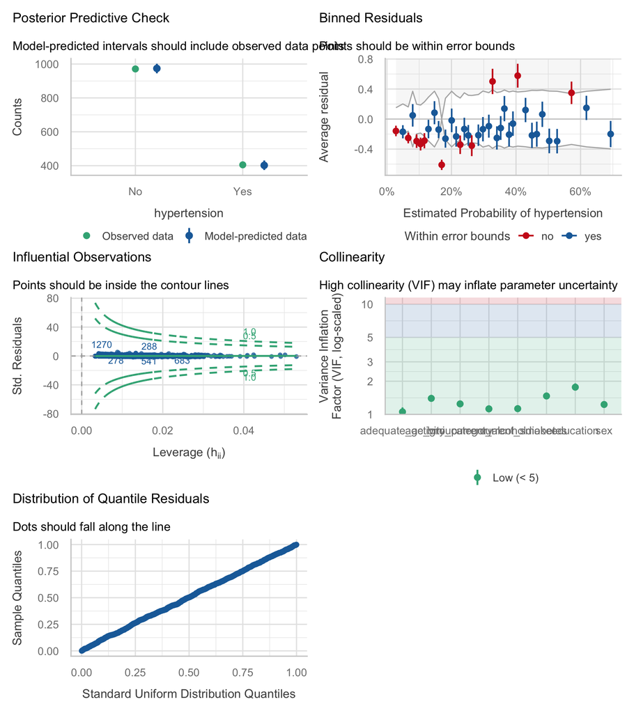

## Sensitivity analysis: prior diagnosis, treatment and the awareness gap

**Table 4. Measured hypertension against self-reported prior diagnosis.**

| Measured hypertension | Prior diagnosis: No | Prior diagnosis: Yes |
| --- | --- | --- |
| No | 826 | 193 |
| Yes | 206 | 219 |

Only 52% of participants who are hypertensive on measurement report a previous diagnosis, and 47% of those who report a previous diagnosis are *not* hypertensive today - the two variables agree on only 72% of participants. Adding `prior_htn_diagnosis` to the model gives an adjusted OR 3.00 (95% CI 2.25 to 4.00), p < 0.001. **This is not an effect of diagnosis on blood pressure and should not be reported as one.** Two opposite mechanisms are tangled in it: a diagnosis was given *because* pressure was high before (raising the OR), and a diagnosis leads to antihypertensive treatment that lowers today’s measured pressure (lowering it). The file records **no medication at all**, so the two cannot be separated. The observed OR above 1 mainly indicates that treatment in this population is not returning pressure to the level of the never-diagnosed; it is reported here as a sensitivity analysis and kept out of the main model.

# Discussion

Among these Kenyan outpatient attenders, age and body size are the characteristics independently associated with hypertension on measured blood pressure: adjusted for the other seven predictors, the over-65s have OR 4.06 (95% CI 2.52 to 6.63) the odds of the 26-35 band and obese attenders OR 2.66 (95% CI 1.89 to 3.75) the odds of healthy-weight attenders. Male sex and current alcohol use add smaller independent associations. The crude association with self-reported diabetes, which looked substantial, is fully explained by age and adiposity, and the apparently protective effect of tertiary education is almost entirely the youth of the educated. Practically, if a clinic can only screen some attenders, age and visible body size are the two things worth acting on, and no reassurance should be taken from a patient’s education or from the absence of a diabetes diagnosis. The awareness gap is stark: 48% of those found hypertensive at this visit had never been told they had hypertension.

**Limitations.** This is a **facility-based convenience sample** of outpatient attenders and not a community sample - attenders are sicker and, here, far better educated and more female than the Kenyan adult population - so the 29% prevalence must not be read as a population prevalence. The design is **cross-sectional**, so nothing here establishes temporality; obesity, alcohol use and blood pressure were all recorded at the same visit. The outcome is a **dichotomised version of a continuous measurement** taken at a single visit, which discards information, makes the results sensitive to the threshold used, and misclassifies anyone whose pressure was atypical that day (white-coat and masked hypertension both exist and neither can be detected here); the continuous `systolic_bp` outcome is statistically the better analysis of the same data. **Antihypertensive medication is not recorded**, which is a serious unmeasured confounder in the wrong direction: treated participants appear non-hypertensive despite higher underlying risk, which biases every coefficient toward the null and makes the observed prevalence an underestimate of underlying disease. **No predictor is continuous**: age is banded and BMI is a WHO category, so residual confounding within band is certain, the binned-residual check fails, and no per-unit statement is possible. Participants come from **three facilities with no facility identifier**, so within-facility correlation cannot be modelled and the standard errors are probably too small. Complete-case analysis dropped 68 rows; `monthly_income` was excluded, so household economic position is unadjusted for. Smoking is rare (89 smokers) and underweight is thin (80 participants), so those two estimates are imprecise. Salt intake, family history and kidney function are absent entirely.

**Future work.** Repeat with continuous age and measured BMI, repeat blood pressure measurement on a second day, and record antihypertensive medication - none of which this extract carries. Modelling `systolic_bp` continuously is a better use of the same file.

# Feasibility notes

*NOT part of a student report.*

- **Works as a student logistic-regression project.** 405 events in 1376 complete cases, 23.8 events per parameter, no separation, maximum VIF 1.77, and two predictors (diabetes, tertiary education) that collapse convincingly on adjustment. That is exactly the Purpose 3 teaching shape.
- **FATAL trap: `systolic_bp` and `diastolic_bp` must never be predictors.** `hypertension` *is* the measured average pressure crossed against a threshold. A student who puts either pressure in the model gets separation or an effectively deterministic model. This is the single most likely way to destroy this analysis and must be stated in the brief.
- **Trap: `prior_htn_diagnosis` is not a clean predictor either.** The relationship is bidirectional - prior diagnosis follows past high pressure but brings treatment that lowers current pressure - and there is **no medication variable in the file** to break the loop. Adjusted OR 3.00 here; a student will interpret it as a risk factor unless warned.
- **THE missing-data teaching case.** `monthly_income` is 31.4% missing; including it drops the sample from 1376 to 968 (67% of the file) and events from 405 to 297, cutting events per parameter from 23.8 to 14.1, and it contributes nothing (LRT p = 0.675). Missingness is patterned by facility (48% private vs 18% faith) and education, so it is not MCAR. Make this a required part of the brief.
- **Binned residuals fail (70.3% of bins inside bounds).** This is structural - all predictors are coarse categories, so only a handful of distinct fitted probabilities exist - and cannot be fixed with this file. Students will otherwise write “diagnostics fine”; they need to be told what the panel means and that this one is not repairable here.
- **`current_smoker` is sparse**: 93 smokers in the file (33 of them hypertensive in the analytic sample), and almost all male. Keep it to one degree of freedom; no interactions.
- **`bmi_category` “Underweight” is thin** (80 people, 10 events) and the strongly protective coefficient is probably reverse causation (illness-related weight loss), not protection.
- **No continuous predictors exist in this file.** Students will try to report odds per year of age or per kg/m2 and cannot.
- **Redundant with `systolic_bp`.** Same question on a thrown-away version of the same measurement. Students should do one or the other; the continuous version is the better analysis, and this one is only preferable if the point of the project is logistic regression.
- **Clustering cannot be modelled** (three facilities, no facility identifier), so standard errors are optimistic.